# Homework 4: Machine Learning

Saagar Hemrajani

2023-06-07

# 1 The Bechdel Test

https://fivethirtyeight.com/features/the-dollar-and-cents-case-against-hollywoods-exclusion-of-women/

The [Bechdel test](https://bechdeltest.com) is a way to assess how women are depicted in Hollywood movies. In order for a movie to pass the test:

1. It has to have at least two [named] women in it
2. Who talk to each other
3. About something besides a man

There is a nice article and analysis you can find here https://fivethirtyeight.com/features/the-dollar-and-cents-case-against-hollywoods-exclusion-of-women/ We have a sample of 1394 movies and we want to fit a model to predict whether a film passes the test or not.

```r
bechdel <- read_csv(here::here("data", "bechdel.csv")) %>%
  mutate(test = factor(test))
glimpse(bechdel)
```

```
## Rows: 1,394
## Columns: 10
## $ year          <dbl> 2013, 2013, 2013, 2013, 2013, 2013, 2013, 2013, 2013, 20…
## $ title         <chr> "12 Years a Slave", "2 Guns", "42", "47 Ronin", "A Good …
## $ test          <fct> Fail, Fail, Fail, Fail, Fail, Pass, Pass, Fail, Pass, Pa…
## $ budget_2013   <dbl> 2.00, 6.10, 4.00, 22.50, 9.20, 1.20, 1.30, 13.00, 4.00, …
## $ domgross_2013 <dbl> 5.3107035, 7.5612460, 9.5020213, 3.8362475, 6.7349198, 1…
## $ intgross_2013 <dbl> 15.8607035, 13.2493015, 9.5020213, 14.5803842, 30.424919…
## $ rated         <chr> "R", "R", "PG-13", "PG-13", "R", "R", "PG-13", "PG-13", …
## $ metascore     <dbl> 97, 55, 62, 29, 28, 55, 48, 33, 90, 58, 52, 78, 83, 53, …
## $ imdb_rating   <dbl> 8.3, 6.8, 7.6, 6.6, 5.4, 7.8, 5.7, 5.0, 7.5, 7.4, 6.2, 7…
## $ genre         <chr> "Biography", "Action", "Biography", "Action", "Action", …
```

How many films fail/pass the test, both as a number and as a %?

```r
  bechdel %>%
    group_by(test) %>%
    summarise(test_count = n()) %>%
    mutate(test_pct = test_count/nrow(bechdel) *100) %>%
    filter(test == 'Pass')
```

```
## # A tibble: 1 × 3
##   test  test_count test_pct
##   <fct>      <int>    <dbl>
## 1 Pass         622     44.6
```

## 1.1 Movie scores

[figure not shown]

```r
ggplot(data = bechdel, aes(
  x = metascore,
  y = imdb_rating,
  colour = test
)) +
  geom_point(alpha = .3, size = 3) +
  scale_colour_manual(values = c("tomato", "olivedrab")) +
  labs(
    x = "Metacritic score",
    y = "IMDB rating",
    colour = "Bechdel test"
  ) +
 theme_light()
```

# 2 Split the data

```r
# **Split the data**

set.seed(123)

data_split <- initial_split(bechdel, # updated data
                           prop = 0.8,
                           strata = test)

bechdel_train <- training(data_split)
bechdel_test <- testing(data_split)
```

Check the counts and % (proportions) of the `test` variable in each set.

```r
count_bechdel <- function(bechdel_df){
  bechdel_df %>%
    group_by(test) %>%
    summarise(test_count = n()) %>%
    mutate(test_pct = test_count/nrow(bechdel_df) *100) %>%
    filter(test == 'Pass')
}

count_bechdel(bechdel_train)
```

```
## # A tibble: 1 × 3
##   test  test_count test_pct
##   <fct>      <int>    <dbl>
## 1 Pass         497     44.6
```

```r
count_bechdel(bechdel_test)
```

```
## # A tibble: 1 × 3
##   test  test_count test_pct
##   <fct>      <int>    <dbl>
## 1 Pass         125     44.6
```

## 2.1 Feature exploration

## 2.2 Any outliers?

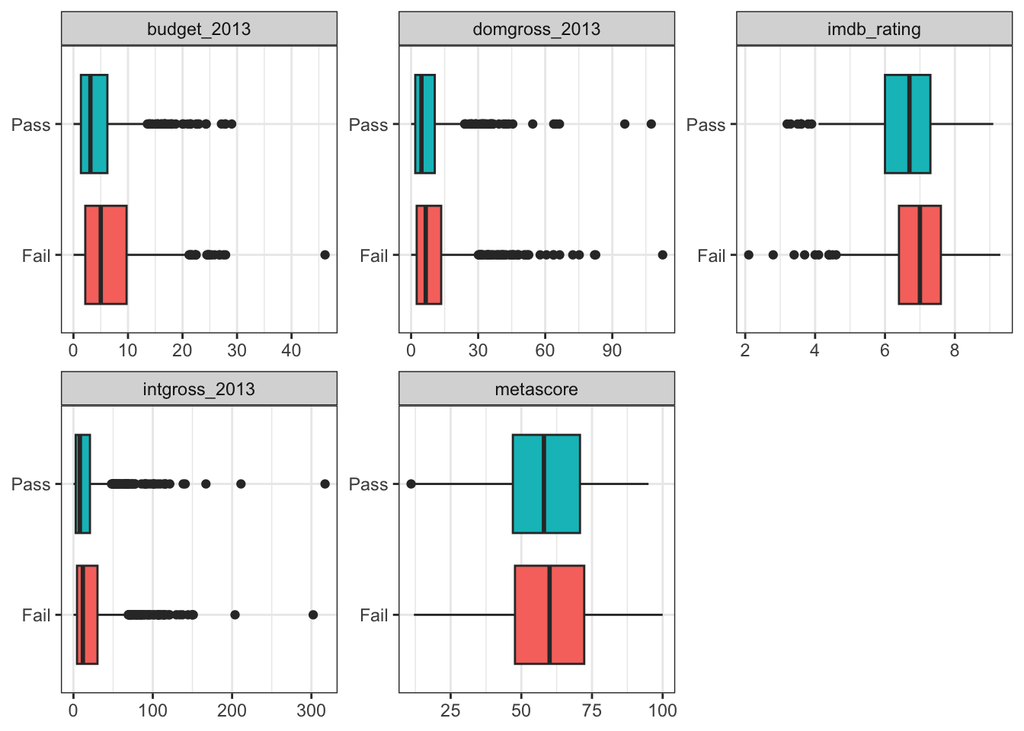

```r
bechdel %>%
  select(test, budget_2013, domgross_2013, intgross_2013, imdb_rating, metascore) %>%

    pivot_longer(cols = 2:6,
               names_to = "feature",
               values_to = "value") %>%
  ggplot()+
  aes(x=test, y = value, fill = test)+
  coord_flip()+
  geom_boxplot()+
  facet_wrap(~feature, scales = "free")+
  theme_bw()+
  theme(legend.position = "none")+
  labs(x=NULL,y = NULL)
```

## 2.3 Scatterplot - Correlation Matrix

Write a paragraph discussing the output of the following

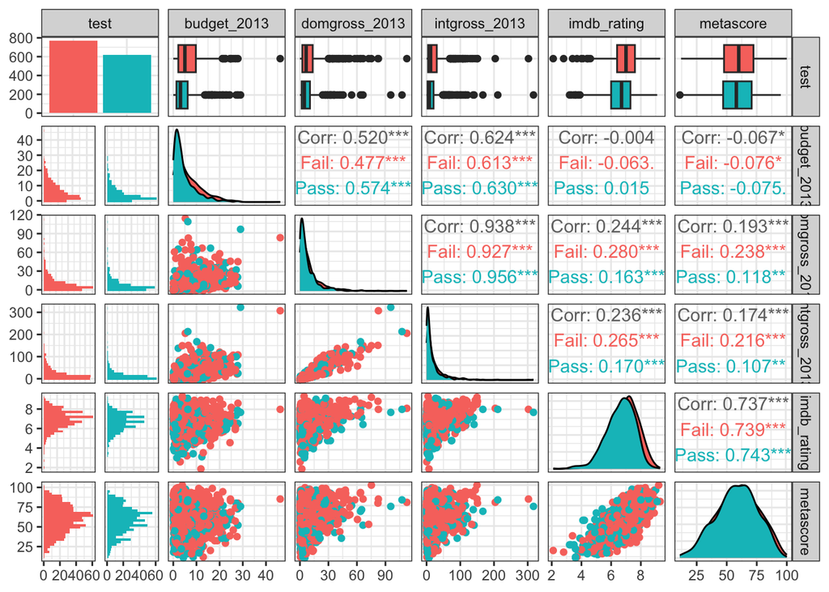

```r
bechdel %>%
  select(test, budget_2013, domgross_2013, intgross_2013, imdb_rating, metascore)%>%
  ggpairs(aes(colour=test), alpha=0.2)+
  theme_bw()
```

Movies that fail the Bechdel test tend to have higher median ratings. The entire box plot is shifted further to the right. This same trend exists with metascore ratings, but the difference in rating is smaller.

Movies that fail the Bechdel test also tend to have higher budgets than those that pass.

## 2.4 Categorical variables

Write a paragraph discussing the output of the following

```r
bechdel %>%
  group_by(genre, test) %>%
  summarise(n = n()) %>%
  mutate(prop = n/sum(n))
```

```
## # A tibble: 24 × 4
## # Groups:   genre [14]
##    genre     test      n  prop
##    <chr>     <fct> <int> <dbl>
##  1 Action    Fail    260 0.707
##  2 Action    Pass    108 0.293
##  3 Adventure Fail     52 0.559
##  4 Adventure Pass     41 0.441
##  5 Animation Fail     63 0.677
##  6 Animation Pass     30 0.323
##  7 Biography Fail     36 0.554
##  8 Biography Pass     29 0.446
##  9 Comedy    Fail    138 0.427
## 10 Comedy    Pass    185 0.573
## # ℹ 14 more rows
```

```r
bechdel %>%
  group_by(rated, test) %>%
  summarise(n = n()) %>%
  mutate(prop = n/sum(n))
```

```
## # A tibble: 10 × 4
## # Groups:   rated [5]
##    rated test      n  prop
##    <chr> <fct> <int> <dbl>
##  1 G     Fail     16 0.615
##  2 G     Pass     10 0.385
##  3 NC-17 Fail      5 0.833
##  4 NC-17 Pass      1 0.167
##  5 PG    Fail    115 0.561
##  6 PG    Pass     90 0.439
##  7 PG-13 Fail    283 0.529
##  8 PG-13 Pass    252 0.471
##  9 R     Fail    353 0.568
## 10 R     Pass    269 0.432
```

Action and animation movies have a lower proportion of movies that pass the test, compared to the whole sample.

Adventure and Biography movies have a similar proportion pass rate to the whole sample.

Comedy movies have an above average pass rate for the test, compared to the sample.

# 3 Train first models. `test ~ metascore + imdb_rating`

```r
lr_mod <- logistic_reg() %>%
  set_engine(engine = "glm") %>%
  set_mode("classification")

lr_mod
```

```
## Logistic Regression Model Specification (classification)
##
## Computational engine: glm
```

```r
tree_mod <- decision_tree() %>%
  set_engine(engine = "C5.0") %>%
  set_mode("classification")

tree_mod
```

```
## Decision Tree Model Specification (classification)
##
## Computational engine: C5.0
```

```r
lr_fit <- lr_mod %>% # parsnip model
  fit(test ~ metascore + imdb_rating, # a formula
    data = bechdel_train # dataframe
  )

tree_fit <- tree_mod %>% # parsnip model
  fit(test ~ metascore + imdb_rating, # a formula
    data = bechdel_train # dataframe
  )
```

## 3.1 Logistic regression

```r
lr_fit %>%
  broom::tidy()
```

```
## # A tibble: 3 × 5
##   term        estimate std.error statistic  p.value
##   <chr>          <dbl>     <dbl>     <dbl>    <dbl>
## 1 (Intercept)   2.80     0.494        5.68 1.35e- 8
## 2 metascore     0.0207   0.00536      3.86 1.13e- 4
## 3 imdb_rating  -0.625    0.100       -6.24 4.36e-10
```

```r
lr_preds <- lr_fit %>%
  augment(new_data = bechdel_train) %>%
  mutate(.pred_match = if_else(test == .pred_Pass, 1, 0))
```

### 3.1.1 Confusion matrix

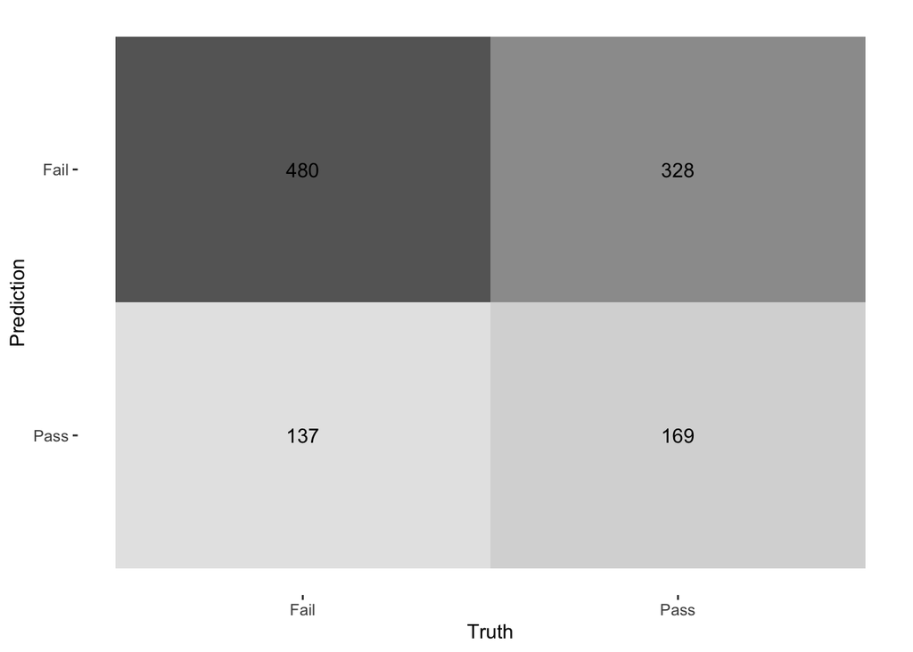

```r
lr_preds %>%
  conf_mat(truth = test, estimate = .pred_class) %>%
  autoplot(type = "heatmap")
```

## 3.2 Decision Tree

```r
tree_preds <- tree_fit %>%
  augment(new_data = bechdel) %>%
  mutate(.pred_match = if_else(test == .pred_Pass, 1, 0))
```

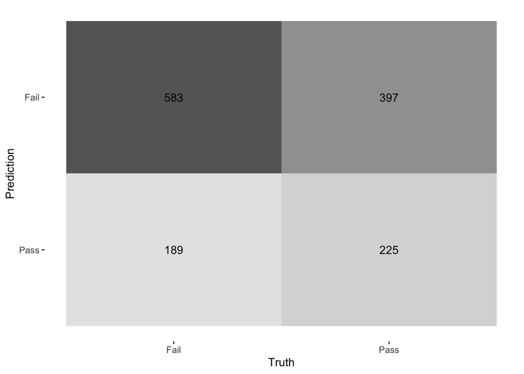

```r
tree_preds %>%
  conf_mat(truth = test, estimate = .pred_class) %>%
  autoplot(type = "heatmap")
```

## 3.3 Draw the decision tree

[figure not shown]

```r
draw_tree <-
    rpart::rpart(
        test ~ metascore + imdb_rating,
        data = bechdel_train, # uses data that contains both birth weight and `low`
        control = rpart::rpart.control(maxdepth = 5, cp = 0, minsplit = 10)
    ) %>%
    partykit::as.party()
plot(draw_tree)
```

# 4 Cross Validation

Run the code below. What does it return?

```r
set.seed(123)
bechdel_folds <- vfold_cv(data = bechdel_train,
                          v = 3,
                          strata = test)
bechdel_folds
```

```
## #  3-fold cross-validation using stratification
## # A tibble: 3 × 2
##   splits            id
##   <list>            <chr>
## 1 <split [742/372]> Fold1
## 2 <split [742/372]> Fold2
## 3 <split [744/370]> Fold3
```

This function returns a dictionary-like data structure with id and split for each cross validation split

## 4.1 `fit_resamples()`

Trains and tests a resampled model.

```r
lr_fit <- lr_mod %>%
  fit_resamples(
    test ~ metascore + imdb_rating,
    resamples = bechdel_folds
  )


tree_fit <- tree_mod %>%
  fit_resamples(
    test ~ metascore + imdb_rating,
    resamples = bechdel_folds
  )
```

## 4.2 `collect_metrics()`

Unnest the metrics column from a tidymodels `fit_resamples()`

```r
collect_metrics(lr_fit)
```

```
## # A tibble: 2 × 6
##   .metric  .estimator  mean     n std_err .config
##   <chr>    <chr>      <dbl> <int>   <dbl> <chr>
## 1 accuracy binary     0.585     3  0.0143 Preprocessor1_Model1
## 2 roc_auc  binary     0.602     3  0.0190 Preprocessor1_Model1
```

```r
collect_metrics(tree_fit)
```

```
## # A tibble: 2 × 6
##   .metric  .estimator  mean     n std_err .config
##   <chr>    <chr>      <dbl> <int>   <dbl> <chr>
## 1 accuracy binary     0.554     3 0.00458 Preprocessor1_Model1
## 2 roc_auc  binary     0.524     3 0.0122  Preprocessor1_Model1
```

```r
tree_preds <- tree_mod %>%
  fit_resamples(
    test ~ metascore + imdb_rating,
    resamples = bechdel_folds,
    control = control_resamples(save_pred = TRUE) #<<
  )

# What does the data for ROC look like?
tree_preds %>%
  collect_predictions() %>%
  roc_curve(truth = test, .pred_Fail)
```

```
## # A tibble: 9 × 3
##   .threshold specificity sensitivity
##        <dbl>       <dbl>       <dbl>
## 1   -Inf          0           1
## 2      0.346      0           1
## 3      0.430      0.0342      0.977
## 4      0.554      0.137       0.890
## 5      0.556      0.471       0.556
## 6      0.569      0.761       0.272
## 7      0.819      0.952       0.0762
## 8      0.867      0.990       0.0276
## 9    Inf          1           0
```

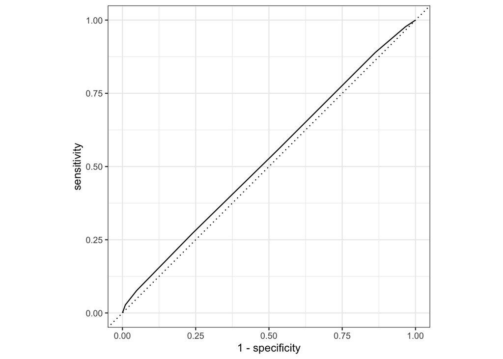

```r
# Draw the ROC
tree_preds %>%
  collect_predictions() %>%
  roc_curve(truth = test, .pred_Fail) %>%
  autoplot()
```

# 5 Build a better training set with `recipes`

## 5.1 Preprocessing options

- Encode categorical predictors
- Center and scale variables
- Handle class imbalance
- Impute missing data
- Perform dimensionality reduction
- … …

## 5.2 To build a recipe

1. Start the `recipe()`
2. Define the variables involved
3. Describe **prep**rocessing [step-by-step]

## 5.3 Collapse Some Categorical Levels

Do we have any `genre` with few observations? Assign genres that have less than 3% to a new category ‘Other’

[figure not shown]

```r
movie_rec <-
  recipe(test ~ .,
         data = bechdel_train) %>%

  # Genres with less than 5% will be in a catewgory 'Other'
    step_other(genre, threshold = .03)
```

## 5.4 Before recipe

```
## # A tibble: 14 × 2
##    genre           n
##    <chr>       <int>
##  1 Action        293
##  2 Comedy        254
##  3 Drama         213
##  4 Adventure      75
##  5 Animation      72
##  6 Crime          68
##  7 Horror         68
##  8 Biography      50
##  9 Mystery         7
## 10 Fantasy         5
## 11 Sci-Fi          3
## 12 Thriller        3
## 13 Documentary     2
## 14 Musical         1
```

## 5.5 After recipe

```r
movie_rec %>%
  prep() %>%
  bake(new_data = bechdel_train) %>%
  count(genre, sort = TRUE)
```

```
## # A tibble: 9 × 2
##   genre         n
##   <fct>     <int>
## 1 Action      293
## 2 Comedy      254
## 3 Drama       213
## 4 Adventure    75
## 5 Animation    72
## 6 Crime        68
## 7 Horror       68
## 8 Biography    50
## 9 other        21
```

## 5.6 `step_dummy()`

Converts nominal data into numeric dummy variables

```r
movie_rec <- recipe(test ~ ., data = bechdel) %>%
  step_other(genre, threshold = .03) %>%
  step_dummy(all_nominal_predictors())

movie_rec
```

```
## ── Recipe ──────────────────────────────────────────────────────────────────────
```

```
## ── Inputs
```

```
## Number of variables by role
```

```
## outcome:   1
## predictor: 9
```

```
## ── Operations
```

```
## • Collapsing factor levels for: genre
```

```
## • Dummy variables from: all_nominal_predictors()
```

## 5.7 Let’s think about the modelling

What if there were no films with `rated` NC-17 in the training data?

- Will the model have a coefficient for `rated` NC-17?
- What will happen if the test data includes a film with `rated` NC-17?

## 5.8 `step_novel()`

Adds a catch-all level to a factor for any new values not encountered in model training, which lets R intelligently predict new levels in the test set.

```r
movie_rec <- recipe(test ~ ., data = bechdel) %>%
  step_other(genre, threshold = .03) %>%
  step_novel(all_nominal_predictors) %>% # Use *before* `step_dummy()` so new level is dummified
  step_dummy(all_nominal_predictors())
```

## 5.9 `step_zv()`

Intelligently handles zero variance variables (variables that contain only a single value)

```r
movie_rec <- recipe(test ~ ., data = bechdel) %>%
  step_other(genre, threshold = .03) %>%
  step_novel(all_nominal(), -all_outcomes()) %>% # Use *before* `step_dummy()` so new level is dummified
  step_dummy(all_nominal(), -all_outcomes()) %>%
  step_zv(all_numeric(), -all_outcomes())
```

## 5.10 `step_normalize()`

Centers then scales numeric variable (mean = 0, sd = 1)

```r
movie_rec <- recipe(test ~ ., data = bechdel) %>%
  step_other(genre, threshold = .03) %>%
  step_novel(all_nominal(), -all_outcomes()) %>% # Use *before* `step_dummy()` so new level is dummified
  step_dummy(all_nominal(), -all_outcomes()) %>%
  step_zv(all_numeric(), -all_outcomes())  %>%
  step_normalize(all_numeric())
```

## 5.11 `step_corr()`

Removes highly correlated variables

```r
movie_rec <- recipe(test ~ ., data = bechdel) %>%
  step_other(genre, threshold = .03) %>%
  step_novel(all_nominal(), -all_outcomes()) %>% # Use *before* `step_dummy()` so new level is dummified
  step_dummy(all_nominal(), -all_outcomes()) %>%
  step_zv(all_numeric(), -all_outcomes())  %>%
  step_normalize(all_numeric())
##%>%
  ##step_corr(all_predictors(), threshold = 0.75, method = "spearman")



movie_rec
```

```
## ── Recipe ──────────────────────────────────────────────────────────────────────
```

```
## ── Inputs
```

```
## Number of variables by role
```

```
## outcome:   1
## predictor: 9
```

```
## ── Operations
```

```
## • Collapsing factor levels for: genre
```

```
## • Novel factor level assignment for: all_nominal(), -all_outcomes()
```

```
## • Dummy variables from: all_nominal(), -all_outcomes()
```

```
## • Zero variance filter on: all_numeric(), -all_outcomes()
```

```
## • Centering and scaling for: all_numeric()
```

# 6 Define different models to fit

```r
## Model Building

# 1. Pick a `model type`
# 2. set the `engine`
# 3. Set the `mode`: regression or classification

# Logistic regression
log_spec <-  logistic_reg() %>%  # model type
  set_engine(engine = "glm") %>%  # model engine
  set_mode("classification") # model mode

# Show your model specification
log_spec
```

```
## Logistic Regression Model Specification (classification)
##
## Computational engine: glm
```

```r
# Decision Tree
tree_spec <- decision_tree() %>%
  set_engine(engine = "C5.0") %>%
  set_mode("classification")

tree_spec
```

```
## Decision Tree Model Specification (classification)
##
## Computational engine: C5.0
```

```r
# Random Forest
library(ranger)

rf_spec <-
  rand_forest() %>%
  set_engine("ranger", importance = "impurity") %>%
  set_mode("classification")


# Boosted tree (XGBoost)
library(xgboost)
xgb_spec <-
  boost_tree() %>%
  set_engine("xgboost") %>%
  set_mode("classification")

# K-nearest neighbour (k-NN)
knn_spec <-
  nearest_neighbor(neighbors = 4) %>% # we can adjust the number of neighbors
  set_engine("kknn") %>%
  set_mode("classification")
```

# 7 Bundle recipe and model with `workflows`

```r
log_wflow <- # new workflow object
 workflow() %>% # use workflow function
 add_recipe(movie_rec) %>%   # use the new recipe
 add_model(log_spec)   # add your model spec

# show object
log_wflow
```

```
## ══ Workflow ════════════════════════════════════════════════════════════════════
## Preprocessor: Recipe
## Model: logistic_reg()
##
## ── Preprocessor ────────────────────────────────────────────────────────────────
## 5 Recipe Steps
##
## • step_other()
## • step_novel()
## • step_dummy()
## • step_zv()
## • step_normalize()
##
## ── Model ───────────────────────────────────────────────────────────────────────
## Logistic Regression Model Specification (classification)
##
## Computational engine: glm
```

```r
## A few more workflows

tree_wflow <-
 workflow() %>%
 add_recipe(movie_rec) %>%
 add_model(tree_spec)

rf_wflow <-
 workflow() %>%
 add_recipe(movie_rec) %>%
 add_model(rf_spec)

xgb_wflow <-
 workflow() %>%
 add_recipe(movie_rec) %>%
 add_model(xgb_spec)

knn_wflow <-
 workflow() %>%
 add_recipe(movie_rec) %>%
 add_model(knn_spec)
```

HEADS UP

1. How many models have you specified?
2. What’s the difference between a model specification and a workflow?
3. Do you need to add a formula (e.g., `test ~ .`) if you have a recipe?

# 8 Model Comparison

You now have all your models. Adapt the code from slides `code-from-slides-CA-housing.R`, line 400 onwards to assess which model gives you the best classification.

```r
## Evaluate Models

## Logistic regression results{.smaller}

log_res <- log_wflow %>%
  fit_resamples(
    resamples = bechdel_folds,
    metrics = metric_set(
      recall, precision, f_meas, accuracy,
      kap, roc_auc, sens, spec),
    control = control_resamples(save_pred = TRUE))
```

```
## → A | warning: glm.fit: algorithm did not converge
```

```
## There were issues with some computations   A: x1
```

```
## → B | warning: prediction from a rank-deficient fit may be misleading
```

[output not shown]

```r
# Show average performance over all folds (note that we use log_res):
log_res %>%  collect_metrics(summarize = TRUE)
```

```
## # A tibble: 8 × 6
##   .metric   .estimator    mean     n std_err .config
##   <chr>     <chr>        <dbl> <int>   <dbl> <chr>
## 1 accuracy  binary      0.434      3  0.0150 Preprocessor1_Model1
## 2 f_meas    binary      0.346      3  0.0772 Preprocessor1_Model1
## 3 kap       binary     -0.0916     3  0.0140 Preprocessor1_Model1
## 4 precision binary      0.470      3  0.0244 Preprocessor1_Model1
## 5 recall    binary      0.290      3  0.0978 Preprocessor1_Model1
## 6 roc_auc   binary      0.450      3  0.0115 Preprocessor1_Model1
## 7 sens      binary      0.290      3  0.0978 Preprocessor1_Model1
## 8 spec      binary      0.614      3  0.0918 Preprocessor1_Model1
```

```r
# Show performance for every single fold:
log_res %>%  collect_metrics(summarize = FALSE)
```

```
## # A tibble: 24 × 5
##    id    .metric   .estimator .estimate .config
##    <chr> <chr>     <chr>          <dbl> <chr>
##  1 Fold1 recall    binary        0.184  Preprocessor1_Model1
##  2 Fold1 precision binary        0.463  Preprocessor1_Model1
##  3 Fold1 f_meas    binary        0.264  Preprocessor1_Model1
##  4 Fold1 accuracy  binary        0.430  Preprocessor1_Model1
##  5 Fold1 kap       binary       -0.0751 Preprocessor1_Model1
##  6 Fold1 sens      binary        0.184  Preprocessor1_Model1
##  7 Fold1 spec      binary        0.735  Preprocessor1_Model1
##  8 Fold1 roc_auc   binary        0.464  Preprocessor1_Model1
##  9 Fold2 recall    binary        0.485  Preprocessor1_Model1
## 10 Fold2 precision binary        0.515  Preprocessor1_Model1
## # ℹ 14 more rows
```

```r
## `collect_predictions()` and get confusion matrix{.smaller}

log_pred <- log_res %>% collect_predictions()

log_pred %>%  conf_mat(test, .pred_class)
```

```
##           Truth
## Prediction Fail Pass
##       Fail  179  192
##       Pass  438  305
```

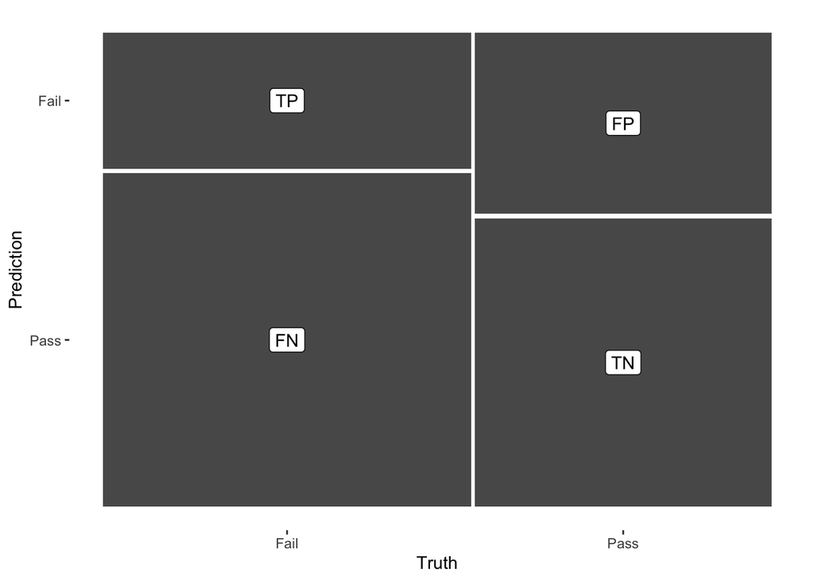

```r
log_pred %>%
  conf_mat(test, .pred_class) %>%
  autoplot(type = "mosaic") +
  geom_label(aes(
      x = (xmax + xmin) / 2,
      y = (ymax + ymin) / 2,
      label = c("TP", "FN", "FP", "TN")))
```

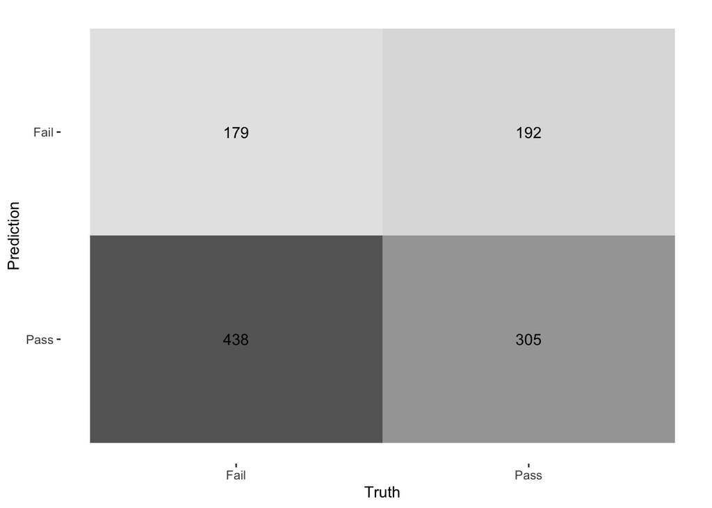

```r
log_pred %>%
  conf_mat(test, .pred_class) %>%
  autoplot(type = "heatmap")
```

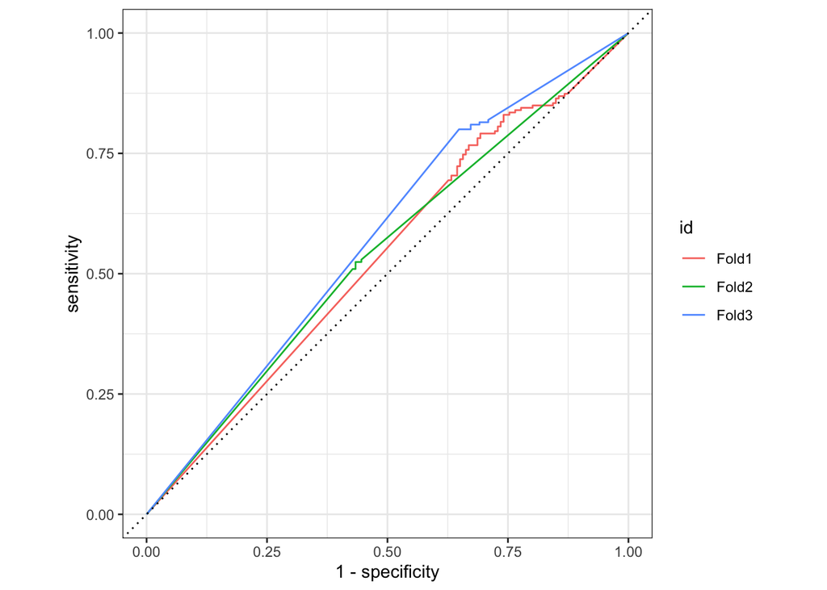

```r
## ROC Curve

log_pred %>%
  group_by(id) %>% # id contains our folds
  roc_curve(test, .pred_Pass) %>%
  autoplot()
```

```r
## Decision Tree results

tree_res <-
  tree_wflow %>%
  fit_resamples(
    resamples = bechdel_folds,
    metrics = metric_set(
      recall, precision, f_meas,
      accuracy, kap,
      roc_auc, sens, spec),
    control = control_resamples(save_pred = TRUE)
    )

tree_res %>%  collect_metrics(summarize = TRUE)
```

```
## # A tibble: 8 × 6
##   .metric   .estimator  mean     n std_err .config
##   <chr>     <chr>      <dbl> <int>   <dbl> <chr>
## 1 accuracy  binary     0.588     3  0.0147 Preprocessor1_Model1
## 2 f_meas    binary     0.633     3  0.0244 Preprocessor1_Model1
## 3 kap       binary     0.163     3  0.0257 Preprocessor1_Model1
## 4 precision binary     0.623     3  0.0105 Preprocessor1_Model1
## 5 recall    binary     0.647     3  0.0473 Preprocessor1_Model1
## 6 roc_auc   binary     0.589     3  0.0151 Preprocessor1_Model1
## 7 sens      binary     0.647     3  0.0473 Preprocessor1_Model1
## 8 spec      binary     0.515     3  0.0393 Preprocessor1_Model1
```

```r
## Random Forest

rf_res <-
  rf_wflow %>%
  fit_resamples(
    resamples = bechdel_folds,
    metrics = metric_set(
      recall, precision, f_meas,
      accuracy, kap,
      roc_auc, sens, spec),
    control = control_resamples(save_pred = TRUE)
    )

rf_res %>%  collect_metrics(summarize = TRUE)
```

```
## # A tibble: 8 × 6
##   .metric   .estimator  mean     n std_err .config
##   <chr>     <chr>      <dbl> <int>   <dbl> <chr>
## 1 accuracy  binary     0.634     3 0.00727 Preprocessor1_Model1
## 2 f_meas    binary     0.702     3 0.00975 Preprocessor1_Model1
## 3 kap       binary     0.238     3 0.0177  Preprocessor1_Model1
## 4 precision binary     0.640     3 0.00999 Preprocessor1_Model1
## 5 recall    binary     0.780     3 0.0332  Preprocessor1_Model1
## 6 roc_auc   binary     0.665     3 0.0140  Preprocessor1_Model1
## 7 sens      binary     0.780     3 0.0332  Preprocessor1_Model1
## 8 spec      binary     0.453     3 0.0448  Preprocessor1_Model1
```

```r
## Boosted tree - XGBoost

xgb_res <-
  xgb_wflow %>%
  fit_resamples(
    resamples = bechdel_folds,
    metrics = metric_set(
      recall, precision, f_meas,
      accuracy, kap,
      roc_auc, sens, spec),
    control = control_resamples(save_pred = TRUE)
    )

xgb_res %>% collect_metrics(summarize = TRUE)
```

```
## # A tibble: 8 × 6
##   .metric   .estimator  mean     n std_err .config
##   <chr>     <chr>      <dbl> <int>   <dbl> <chr>
## 1 accuracy  binary     0.606     3 0.00256 Preprocessor1_Model1
## 2 f_meas    binary     0.657     3 0.0107  Preprocessor1_Model1
## 3 kap       binary     0.195     3 0.00120 Preprocessor1_Model1
## 4 precision binary     0.634     3 0.00426 Preprocessor1_Model1
## 5 recall    binary     0.684     3 0.0288  Preprocessor1_Model1
## 6 roc_auc   binary     0.635     3 0.00299 Preprocessor1_Model1
## 7 sens      binary     0.684     3 0.0288  Preprocessor1_Model1
## 8 spec      binary     0.509     3 0.0303  Preprocessor1_Model1
```

```r
## K-nearest neighbour

knn_res <-
  knn_wflow %>%
  fit_resamples(
    resamples = bechdel_folds,
    metrics = metric_set(
      recall, precision, f_meas,
      accuracy, kap,
      roc_auc, sens, spec),
    control = control_resamples(save_pred = TRUE)
    )
```

[output not shown]

```r
knn_res %>% collect_metrics(summarize = TRUE)
```

```
## # A tibble: 8 × 6
##   .metric   .estimator  mean     n  std_err .config
##   <chr>     <chr>      <dbl> <int>    <dbl> <chr>
## 1 accuracy  binary     0.518     3 0.0359   Preprocessor1_Model1
## 2 f_meas    binary     0.713     2 0.000120 Preprocessor1_Model1
## 3 kap       binary     0         3 0        Preprocessor1_Model1
## 4 precision binary     0.554     2 0.000145 Preprocessor1_Model1
## 5 recall    binary     0.667     3 0.333    Preprocessor1_Model1
## 6 roc_auc   binary     0.553     3 0.0284   Preprocessor1_Model1
## 7 sens      binary     0.667     3 0.333    Preprocessor1_Model1
## 8 spec      binary     0.333     3 0.333    Preprocessor1_Model1
```

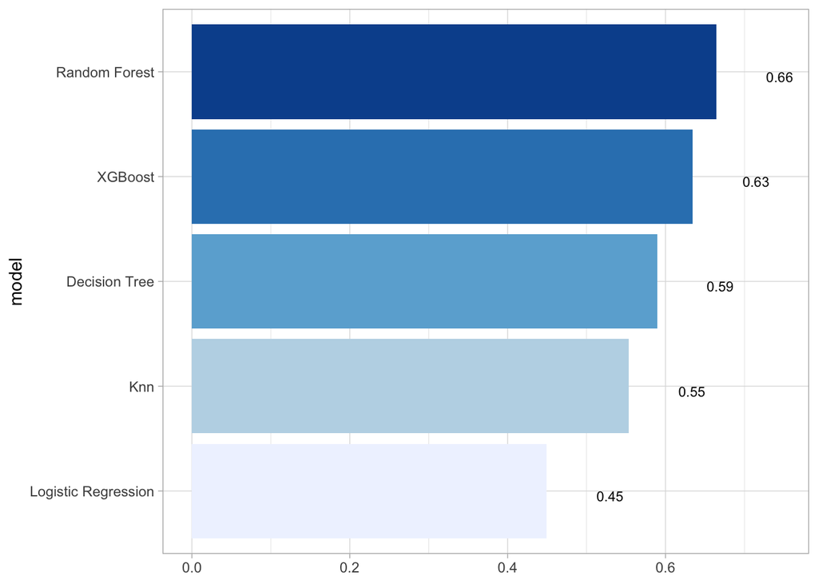

```r
## Model Comparison

log_metrics <-
  log_res %>%
  collect_metrics(summarise = TRUE) %>%
  # add the name of the model to every row
  mutate(model = "Logistic Regression")

tree_metrics <-
  tree_res %>%
  collect_metrics(summarise = TRUE) %>%
  mutate(model = "Decision Tree")

rf_metrics <-
  rf_res %>%
  collect_metrics(summarise = TRUE) %>%
  mutate(model = "Random Forest")

xgb_metrics <-
  xgb_res %>%
  collect_metrics(summarise = TRUE) %>%
  mutate(model = "XGBoost")

knn_metrics <-
  knn_res %>%
  collect_metrics(summarise = TRUE) %>%
  mutate(model = "Knn")

# create dataframe with all models
model_compare <- bind_rows(log_metrics,
                           tree_metrics,
                           rf_metrics,
                           xgb_metrics,
                           knn_metrics)

#Pivot wider to create barplot
  model_comp <- model_compare %>%
  select(model, .metric, mean, std_err) %>%
  pivot_wider(names_from = .metric, values_from = c(mean, std_err))

# show mean are under the curve (ROC-AUC) for every model
model_comp %>%
  arrange(mean_roc_auc) %>%
  mutate(model = fct_reorder(model, mean_roc_auc)) %>% # order results
  ggplot(aes(model, mean_roc_auc, fill=model)) +
  geom_col() +
  coord_flip() +
  scale_fill_brewer(palette = "Blues") +
   geom_text(
     size = 3,
     aes(label = round(mean_roc_auc, 2),
         y = mean_roc_auc + 0.08),
     vjust = 1
  )+
  theme_light()+
  theme(legend.position = "none")+
  labs(y = NULL)
```

```r
## `last_fit()` on test set

# - `last_fit()`  fits a model to the whole training data and evaluates it on the test set.
# - provide the workflow object of the best model as well as the data split object (not the training data).

last_fit_xgb <- last_fit(xgb_wflow,
                        split = data_split,
                        metrics = metric_set(
                          accuracy, f_meas, kap, precision,
                          recall, roc_auc, sens, spec))

last_fit_xgb %>% collect_metrics(summarize = TRUE)
```

```
## # A tibble: 8 × 4
##   .metric   .estimator .estimate .config
##   <chr>     <chr>          <dbl> <chr>
## 1 accuracy  binary         0.568 Preprocessor1_Model1
## 2 f_meas    binary         0.630 Preprocessor1_Model1
## 3 kap       binary         0.114 Preprocessor1_Model1
## 4 precision binary         0.599 Preprocessor1_Model1
## 5 recall    binary         0.665 Preprocessor1_Model1
## 6 sens      binary         0.665 Preprocessor1_Model1
## 7 spec      binary         0.448 Preprocessor1_Model1
## 8 roc_auc   binary         0.610 Preprocessor1_Model1
```

```r
#Compare to training
xgb_res %>% collect_metrics(summarize = TRUE)
```

```
## # A tibble: 8 × 6
##   .metric   .estimator  mean     n std_err .config
##   <chr>     <chr>      <dbl> <int>   <dbl> <chr>
## 1 accuracy  binary     0.606     3 0.00256 Preprocessor1_Model1
## 2 f_meas    binary     0.657     3 0.0107  Preprocessor1_Model1
## 3 kap       binary     0.195     3 0.00120 Preprocessor1_Model1
## 4 precision binary     0.634     3 0.00426 Preprocessor1_Model1
## 5 recall    binary     0.684     3 0.0288  Preprocessor1_Model1
## 6 roc_auc   binary     0.635     3 0.00299 Preprocessor1_Model1
## 7 sens      binary     0.684     3 0.0288  Preprocessor1_Model1
## 8 spec      binary     0.509     3 0.0303  Preprocessor1_Model1
```

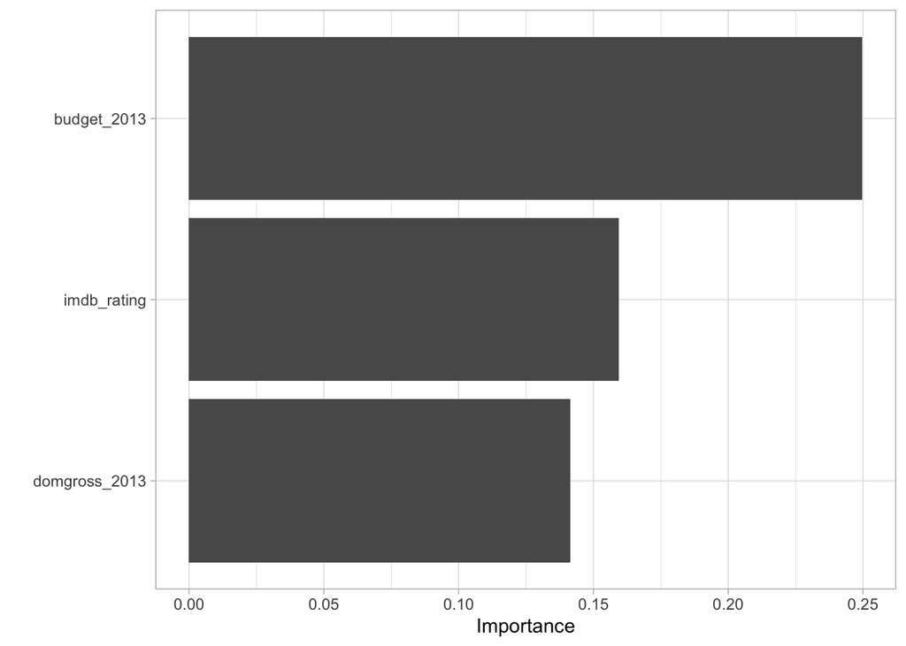

```r
## Variable importance using `{vip}` package

library(vip)

last_fit_xgb %>%
  pluck(".workflow", 1) %>%
  pull_workflow_fit() %>%
  vip(num_features = 3) +
  theme_light()
```

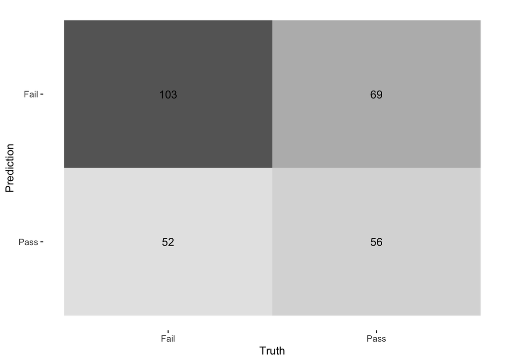

```r
## Final Confusion Matrix

last_fit_xgb %>%
  collect_predictions() %>%
  conf_mat(test, .pred_class) %>%
  autoplot(type = "heatmap")
```

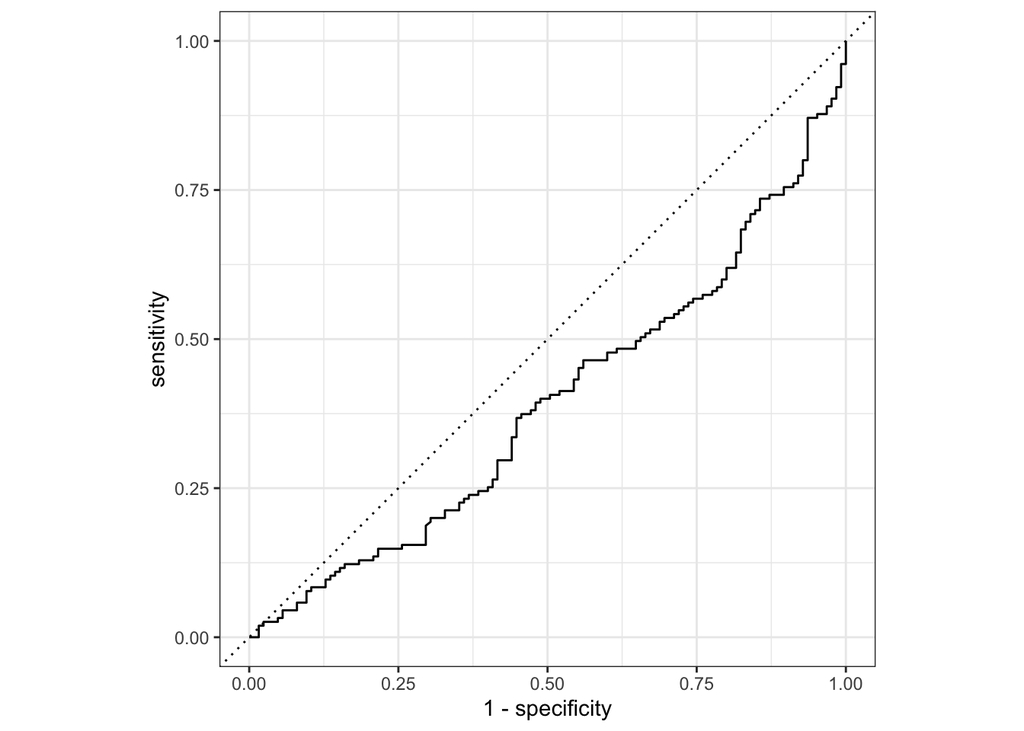

```r
## Final ROC curve
last_fit_xgb %>%
  collect_predictions() %>%
  roc_curve(test, .pred_Pass) %>%
  autoplot()
```

Random forest has highest average area under curve. This means it has highest precision and accuracy

XGBoost is the next highest AUC, this suggests that the sequential optimizing nature of xgboost is less effective classifier than an ensemble model

# 9 Details

- Approximately how much time did you spend on this problem set: 3 hrs